# Projet GLM V3

David TAVEL

09/01/2022

## Présentation

A partir du jeu de données d'entrainement meteo.train nous allons tenter d'établir un modèle de prédiction, afin de prédire s'il va pleuvoir le lendemain. Nous appliquerons le modèle aux données issues du fichier test meteo.test afin d'éprouver notre modèle.

| X | Year | Month | Day | Hour | Minute | Temperature.daily.mean..2.m.above.gnd. | Relative.Humidity.daily.mean..2.m.above.gnd. | Mean.Sea.Level.Pressure.daily.mean..MSL. | Total.Precipitation.daily.sum..sfc. | Snowfall.amount.raw.daily.sum..sfc. | Total.Cloud.Cover.daily.mean..sfc. | High.Cloud.Cover.daily.mean..high.cld.lay. | Medium.Cloud.Cover.daily.mean..mid.cld.lay. | Low.Cloud.Cover.daily.mean..low.cld.lay. | Sunshine.Duration.daily.sum..sfc. | Shortwave.Radiation.daily.sum..sfc. | Wind.Speed.daily.mean..10.m.above.gnd. | Wind.Direction.daily.mean..10.m.above.gnd. | Wind.Speed.daily.mean..80.m.above.gnd. | Wind.Direction.daily.mean..80.m.above.gnd. | Wind.Speed.daily.mean..900.mb. | Wind.Direction.daily.mean..900.mb. | Wind.Gust.daily.mean..sfc. | Temperature.daily.max..2.m.above.gnd. | Temperature.daily.min..2.m.above.gnd. | Relative.Humidity.daily.max..2.m.above.gnd. | Relative.Humidity.daily.min..2.m.above.gnd. | Mean.Sea.Level.Pressure.daily.max..MSL. | Mean.Sea.Level.Pressure.daily.min..MSL. | … |
| --- | --- | --- | --- | --- | --- | --- | --- | --- | --- | --- | --- | --- | --- | --- | --- | --- | --- | --- | --- | --- | --- | --- | --- | --- | --- | --- | --- | --- | --- | --- |
| 2 | 2010 | 6 | 2 | 0 | 0 | 14.99 | 76.46 | 1014.99 | 1.0 | 0 | 79.79 | 3.00 | 31.58 | 79.21 | 287.23 | 6709.71 | 11.64 | 274.72 | 14.99 | 267.89 | 20.60 | 180.40 | 14.88 | 18.49 | 11.11 | 94 | 59 | 1016.6 | 1013.9 | … |
| 4 | 2010 | 6 | 4 | 0 | 0 | 17.31 | 77.62 | 1017.26 | 0.0 | 0 | 4.70 | 0.67 | 0.00 | 4.50 | 821.40 | 7974.40 | 6.34 | 229.69 | 8.92 | 199.23 | 27.87 | 93.72 | 9.48 | 24.98 | 10.45 | 92 | 54 | 1018.7 | 1015.9 | … |
| 6 | 2010 | 6 | 6 | 0 | 0 | 21.62 | 69.50 | 1014.59 | 3.7 | 0 | 42.09 | 21.21 | 25.92 | 35.29 | 441.32 | 4833.59 | 8.40 | 214.62 | 10.38 | 207.80 | 18.88 | 250.08 | 13.50 | 26.25 | 17.69 | 91 | 57 | 1015.7 | 1012.6 | … |
| 8 | 2010 | 6 | 8 | 0 | 0 | 20.22 | 75.08 | 1007.74 | 0.2 | 0 | 67.45 | 54.71 | 65.79 | 18.92 | 41.91 | 5389.84 | 5.40 | 204.97 | 6.53 | 205.83 | 10.44 | 238.57 | 5.31 | 24.17 | 14.68 | 89 | 62 | 1010.2 | 1005.6 | … |
| 10 | 2010 | 6 | 10 | 0 | 0 | 22.64 | 73.46 | 1003.81 | 0.0 | 0 | 56.32 | 50.25 | 55.33 | 34.21 | 473.23 | 7216.12 | 9.16 | 179.23 | 11.91 | 185.71 | 21.89 | 152.96 | 12.21 | 30.72 | 16.92 | 97 | 39 | 1005.7 | 1001.4 | … |

## Introduction

Notre jeu de données se compose de 47 variables. 7 variables qualitatives et 40 variables quantitaves. Nous souhaitons expliquer la variable qualitative *pluie.demain* à partir d'autres variables séléctionnées parmi les 46 restantes, les variables explicatives. Pour ce faire nous procèderons comme suit :  
- nous séléctionnerons un nombre limité de variables parmi les 46  
- nous construirons plusieurs modèles à partir de notre sélection  
- nous séléctionnerons le modèle qui semble le plus pertinent pour faire notre prédiction

## I- Séléction de variable

Au vu du problème posé, nous partirons sur un jeu de données minimum en supprimant les colonnes *X, Year, Day, Hour, Minute.*

| Month | Temperature.daily.mean..2.m.above.gnd. | Relative.Humidity.daily.mean..2.m.above.gnd. | Mean.Sea.Level.Pressure.daily.mean..MSL. | Total.Precipitation.daily.sum..sfc. | Snowfall.amount.raw.daily.sum..sfc. | Total.Cloud.Cover.daily.mean..sfc. | High.Cloud.Cover.daily.mean..high.cld.lay. | Medium.Cloud.Cover.daily.mean..mid.cld.lay. | Low.Cloud.Cover.daily.mean..low.cld.lay. | Sunshine.Duration.daily.sum..sfc. | Shortwave.Radiation.daily.sum..sfc. | Wind.Speed.daily.mean..10.m.above.gnd. | Wind.Direction.daily.mean..10.m.above.gnd. | Wind.Speed.daily.mean..80.m.above.gnd. | Wind.Direction.daily.mean..80.m.above.gnd. | Wind.Speed.daily.mean..900.mb. | Wind.Direction.daily.mean..900.mb. | Wind.Gust.daily.mean..sfc. | Temperature.daily.max..2.m.above.gnd. | Temperature.daily.min..2.m.above.gnd. | Relative.Humidity.daily.max..2.m.above.gnd. | Relative.Humidity.daily.min..2.m.above.gnd. | Mean.Sea.Level.Pressure.daily.max..MSL. | Mean.Sea.Level.Pressure.daily.min..MSL. | Total.Cloud.Cover.daily.max..sfc. | Total.Cloud.Cover.daily.min..sfc. | High.Cloud.Cover.daily.max..high.cld.lay. | High.Cloud.Cover.daily.min..high.cld.lay. | Medium.Cloud.Cover.daily.max..mid.cld.lay. | … |
| --- | --- | --- | --- | --- | --- | --- | --- | --- | --- | --- | --- | --- | --- | --- | --- | --- | --- | --- | --- | --- | --- | --- | --- | --- | --- | --- | --- | --- | --- | --- |
| 6 | 14.99 | 76.46 | 1014.99 | 1.0 | 0 | 79.79 | 3.00 | 31.58 | 79.21 | 287.23 | 6709.71 | 11.64 | 274.72 | 14.99 | 267.89 | 20.60 | 180.40 | 14.88 | 18.49 | 11.11 | 94 | 59 | 1016.6 | 1013.9 | 100 | 0 | 16 | 0 | 100 | … |
| 6 | 17.31 | 77.62 | 1017.26 | 0.0 | 0 | 4.70 | 0.67 | 0.00 | 4.50 | 821.40 | 7974.40 | 6.34 | 229.69 | 8.92 | 199.23 | 27.87 | 93.72 | 9.48 | 24.98 | 10.45 | 92 | 54 | 1018.7 | 1015.9 | 28 | 0 | 11 | 0 | 0 | … |
| 6 | 21.62 | 69.50 | 1014.59 | 3.7 | 0 | 42.09 | 21.21 | 25.92 | 35.29 | 441.32 | 4833.59 | 8.40 | 214.62 | 10.38 | 207.80 | 18.88 | 250.08 | 13.50 | 26.25 | 17.69 | 91 | 57 | 1015.7 | 1012.6 | 100 | 0 | 100 | 0 | 100 | … |
| 6 | 20.22 | 75.08 | 1007.74 | 0.2 | 0 | 67.45 | 54.71 | 65.79 | 18.92 | 41.91 | 5389.84 | 5.40 | 204.97 | 6.53 | 205.83 | 10.44 | 238.57 | 5.31 | 24.17 | 14.68 | 89 | 62 | 1010.2 | 1005.6 | 100 | 0 | 100 | 0 | 100 | … |
| 6 | 22.64 | 73.46 | 1003.81 | 0.0 | 0 | 56.32 | 50.25 | 55.33 | 34.21 | 473.23 | 7216.12 | 9.16 | 179.23 | 11.91 | 185.71 | 21.89 | 152.96 | 12.21 | 30.72 | 16.92 | 97 | 39 | 1005.7 | 1001.4 | 100 | 0 | 100 | 0 | 100 | … |

### I-1 Comparaison entre les deux groupes : Analyse descriptive.

On peut considérer que notre échantillon est constitué de 2 groupes. Le groupe il va pleuvoir demain (*pluie.demain*=TRUE) et le groupe il ne pleuvera pas demain (*pluie.demain*=FALSE).

Cherchons à savoir si certaines variables ont des valeurs statistiquements différentes entre les 2 groupes.

#### I-1-a Comparaison des variables quantitatives : Test de Welch

A l'aide d'un test de Welch nous allons pour chaque variable regarder s'il existe une différence significative entre les 2 groupes.

| nom.variable | iqr.pluie.median | iqr.soleil.median | p.value |
| --- | --- | --- | --- |
| Month | [1-12] 6.27 | [1-12] 6.61 | 8.222986e-02 |
| Temperature.daily.mean..2.m.above.gnd. | [-5.59-28.88] 13.03 | [-7.63-29.45] 11.39 | 4.813819e-05 |
| Relative.Humidity.daily.mean..2.m.above.gnd. | [38.33-94.17] 71.64 | [44.17-95.54] 71.15 | 3.740121e-01 |
| Mean.Sea.Level.Pressure.daily.mean..MSL. | [978.93-1037.79] 1014.14 | [997.85-1042.4] 1020.04 | 5.130266e-40 |
| Total.Precipitation.daily.sum..sfc. | [0-31.5] 3.06 | [0-26.5] 1.07 | 9.477907e-18 |
| Snowfall.amount.raw.daily.sum..sfc. | [0-3.36] 0.05 | [0-8.61] 0.05 | 9.160707e-01 |
| Total.Cloud.Cover.daily.mean..sfc. | [0-100] 60.79 | [0-100] 40.35 | 8.584095e-30 |
| High.Cloud.Cover.daily.mean..high.cld.lay. | [0-100] 26.62 | [0-90.83] 13.71 | 2.190860e-25 |
| Medium.Cloud.Cover.daily.mean..mid.cld.lay. | [0-100] 42.81 | [0-100] 19.77 | 1.142709e-43 |
| Low.Cloud.Cover.daily.mean..low.cld.lay. | [0-100] 46.3 | [0-100] 32.12 | 2.078240e-15 |
| Sunshine.Duration.daily.sum..sfc. | [0-1015.83] 307.1 | [0-977.98] 441.58 | 1.617138e-17 |
| Shortwave.Radiation.daily.sum..sfc. | [265.22-8304.59] 3863.35 | [428.98-8363.33] 4110.45 | 4.849633e-02 |
| Wind.Speed.daily.mean..10.m.above.gnd. | [1.26-42.21] 11.98 | [2.06-31.78] 9.38 | 1.450238e-13 |
| Wind.Direction.daily.mean..10.m.above.gnd. | [81.64-331.67] 209.35 | [11.19-323] 194 | 1.909220e-05 |
| Wind.Speed.daily.mean..80.m.above.gnd. | [1.34-54.03] 15.81 | [2.83-42.09] 12.7 | 6.842407e-12 |
| Wind.Direction.daily.mean..80.m.above.gnd. | [61.98-333.43] 214.35 | [12.18-329.41] 197.81 | 5.120263e-06 |
| Wind.Speed.daily.mean..900.mb. | [2.25-97.06] 27.49 | [2.27-77.02] 21.53 | 1.029745e-10 |
| Wind.Direction.daily.mean..900.mb. | [17.37-337.56] 223.83 | [38.34-344.82] 187.95 | 7.229881e-17 |
| Wind.Gust.daily.mean..sfc. | [2.72-79.38] 18.99 | [2.25-46.3] 14.29 | 1.197472e-15 |
| Temperature.daily.max..2.m.above.gnd. | [-0.88-35.77] 17.21 | [-3.84-35.1] 15.84 | 2.112091e-03 |
| Temperature.daily.min..2.m.above.gnd. | [-10.56-22.5] 8.97 | [-12.52-23.94] 7.12 | 5.062830e-07 |
| Relative.Humidity.daily.max..2.m.above.gnd. | [59-100] 87.66 | [59-100] 87.71 | 9.203440e-01 |
| Relative.Humidity.daily.min..2.m.above.gnd. | [19-90] 54.41 | [25-92] 53.66 | 3.047698e-01 |
| Mean.Sea.Level.Pressure.daily.max..MSL. | [981.9-1041.3] 1017.25 | [1002.4-1045.4] 1022.61 | 1.400017e-35 |
| Mean.Sea.Level.Pressure.daily.min..MSL. | [977-1035.3] 1010.95 | [993.7-1038.6] 1017.51 | 1.425958e-43 |
| Total.Cloud.Cover.daily.max..sfc. | [0-100] 96.01 | [0-100] 80.16 | 3.062008e-20 |
| Total.Cloud.Cover.daily.min..sfc. | [0-100] 12.3 | [0-100] 4.95 | 2.512723e-08 |
| High.Cloud.Cover.daily.max..high.cld.lay. | [0-100] 74.26 | [0-100] 45.54 | 6.389489e-32 |
| High.Cloud.Cover.daily.min..high.cld.lay. | [0-100] 1.36 | [0-37] 0.51 | 3.270483e-03 |
| Medium.Cloud.Cover.daily.max..mid.cld.lay. | [0-100] 87.59 | [0-100] 53.66 | 8.006229e-45 |
| Medium.Cloud.Cover.daily.min..mid.cld.lay. | [0-100] 3.18 | [0-100] 0.97 | 6.734570e-04 |
| Low.Cloud.Cover.daily.max..low.cld.lay. | [0-100] 88.48 | [0-100] 71.21 | 8.778247e-15 |
| Low.Cloud.Cover.daily.min..low.cld.lay. | [0-100] 5.17 | [0-100] 2.54 | 6.678404e-03 |
| Wind.Speed.daily.max..10.m.above.gnd. | [2.52-79.99] 21.35 | [4.1-43.53] 16.69 | 3.439937e-18 |
| Wind.Speed.daily.min..10.m.above.gnd. | [0-27.73] 4.2 | [0-20.67] 2.92 | 5.496778e-09 |
| Wind.Speed.daily.max..80.m.above.gnd. | [3.98-93.84] 27.98 | [5.62-55.83] 22.63 | 1.122047e-17 |
| Wind.Speed.daily.min..80.m.above.gnd. | [0-37.7] 5.47 | [0-28.79] 3.95 | 3.324276e-06 |
| Wind.Speed.daily.max..900.mb. | [4.02-136.25] 47.07 | [4.69-106.61] 36.37 | 8.990877e-17 |
| Wind.Speed.daily.min..900.mb. | [0-76.13] 12.5 | [0-62.3] 9.62 | 2.791468e-05 |
| Wind.Gust.daily.max..sfc. | [4.32-95.04] 33.34 | [5.4-67.32] 25.13 | 2.956137e-22 |
| Wind.Gust.daily.min..sfc. | [0-57.96] 7.69 | [0-33.12] 5.27 | 3.682190e-09 |

*Tableau descriptif des variables en fonction des 2 groupes*

On ne va conserver que les variables avec une **p.value < 0.01**.

| Month | Temperature.daily.mean..2.m.above.gnd. | Mean.Sea.Level.Pressure.daily.mean..MSL. | Total.Precipitation.daily.sum..sfc. | Total.Cloud.Cover.daily.mean..sfc. | High.Cloud.Cover.daily.mean..high.cld.lay. | Medium.Cloud.Cover.daily.mean..mid.cld.lay. | Low.Cloud.Cover.daily.mean..low.cld.lay. | Sunshine.Duration.daily.sum..sfc. | Wind.Speed.daily.mean..10.m.above.gnd. | Wind.Direction.daily.mean..10.m.above.gnd. | Wind.Speed.daily.mean..80.m.above.gnd. | Wind.Direction.daily.mean..80.m.above.gnd. | Wind.Speed.daily.mean..900.mb. | Wind.Direction.daily.mean..900.mb. | Wind.Gust.daily.mean..sfc. | Temperature.daily.max..2.m.above.gnd. | Temperature.daily.min..2.m.above.gnd. | Mean.Sea.Level.Pressure.daily.max..MSL. | Mean.Sea.Level.Pressure.daily.min..MSL. | Total.Cloud.Cover.daily.max..sfc. | Total.Cloud.Cover.daily.min..sfc. | High.Cloud.Cover.daily.max..high.cld.lay. | High.Cloud.Cover.daily.min..high.cld.lay. | Medium.Cloud.Cover.daily.max..mid.cld.lay. | Medium.Cloud.Cover.daily.min..mid.cld.lay. | Low.Cloud.Cover.daily.max..low.cld.lay. | Low.Cloud.Cover.daily.min..low.cld.lay. | Wind.Speed.daily.max..10.m.above.gnd. | Wind.Speed.daily.min..10.m.above.gnd. | … |
| --- | --- | --- | --- | --- | --- | --- | --- | --- | --- | --- | --- | --- | --- | --- | --- | --- | --- | --- | --- | --- | --- | --- | --- | --- | --- | --- | --- | --- | --- | --- |
| 6 | 14.99 | 1014.99 | 1.0 | 79.79 | 3.00 | 31.58 | 79.21 | 287.23 | 11.64 | 274.72 | 14.99 | 267.89 | 20.60 | 180.40 | 14.88 | 18.49 | 11.11 | 1016.6 | 1013.9 | 100 | 0 | 16 | 0 | 100 | 0 | 100 | 0 | 22.01 | 5.62 | … |
| 6 | 17.31 | 1017.26 | 0.0 | 4.70 | 0.67 | 0.00 | 4.50 | 821.40 | 6.34 | 229.69 | 8.92 | 199.23 | 27.87 | 93.72 | 9.48 | 24.98 | 10.45 | 1018.7 | 1015.9 | 28 | 0 | 11 | 0 | 0 | 0 | 28 | 0 | 15.52 | 1.08 | … |
| 6 | 21.62 | 1014.59 | 3.7 | 42.09 | 21.21 | 25.92 | 35.29 | 441.32 | 8.40 | 214.62 | 10.38 | 207.80 | 18.88 | 250.08 | 13.50 | 26.25 | 17.69 | 1015.7 | 1012.6 | 100 | 0 | 100 | 0 | 100 | 0 | 100 | 0 | 22.71 | 2.41 | … |
| 6 | 20.22 | 1007.74 | 0.2 | 67.45 | 54.71 | 65.79 | 18.92 | 41.91 | 5.40 | 204.97 | 6.53 | 205.83 | 10.44 | 238.57 | 5.31 | 24.17 | 14.68 | 1010.2 | 1005.6 | 100 | 0 | 100 | 0 | 100 | 0 | 100 | 0 | 10.70 | 0.00 | … |
| 6 | 22.64 | 1003.81 | 0.0 | 56.32 | 50.25 | 55.33 | 34.21 | 473.23 | 9.16 | 179.23 | 11.91 | 185.71 | 21.89 | 152.96 | 12.21 | 30.72 | 16.92 | 1005.7 | 1001.4 | 100 | 0 | 100 | 0 | 100 | 0 | 100 | 0 | 20.46 | 2.52 | … |
| 6 | 18.44 | 1012.00 | 2.2 | 68.85 | 1.67 | 5.25 | 67.92 | 217.22 | 8.04 | 219.80 | 10.85 | 224.74 | 20.21 | 263.24 | 13.69 | 22.04 | 14.31 | 1013.5 | 1010.4 | 100 | 0 | 28 | 0 | 100 | 0 | 100 | 0 | 19.35 | 2.28 | … |

On a conservé 36 variables, ce qui reste encore important.

Intéressons-nous à la seule variable qualitative *Month.*

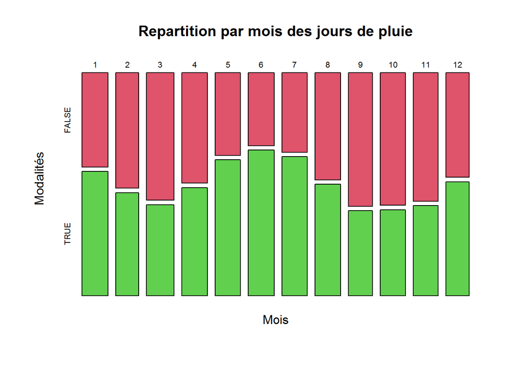

Il semblerait qu'il y ait une tendance en fonction des mois de l'année, avec plus de précipitation en janvier, mai, juin et juillet. Faisons un test du Chi² pour voir s'il existe une différence statistiquement significative entre les deux groupes.

```
##
##  Pearson's Chi-squared test
##
## data:  tab.mois
## X-squared = 41.685, df = 11, p-value = 1.836e-05
```

Il semblerait qu'il y ait une différence statistiquement significative entre les deux groupes. On va donc garder la variable *Month* dans le modèle.

A ce stade, 37 variables explicatives seraient intégrées à notre modèle, ce qui risque d'être difficilement ajustable. Tentons une approche pas à pas en vérifiant que les variables séléctionnées sont parmi nos 37 variables.

### I-2 Approche pas à pas.

#### I-2 Approche pas à pas descendante.

```
## Start:  AIC=1716.46
## pluie.demain ~ 1
```

```
##
## Call:
## glm(formula = pluie.demain ~ 1, data = meteo.train.min)
##
## Deviance Residuals:
##     Min       1Q   Median       3Q      Max
## -0.5093  -0.5093   0.4907   0.4907   0.4907
##
## Coefficients:
##             Estimate Std. Error t value Pr(>|t|)
## (Intercept)  0.50932    0.01456   34.98   <2e-16 ***
## ---
## Signif. codes:  0 '***' 0.001 '**' 0.01 '*' 0.05 '.' 0.1 ' ' 1
##
## (Dispersion parameter for gaussian family taken to be 0.2501251)
##
##     Null deviance: 294.9  on 1179  degrees of freedom
## Residual deviance: 294.9  on 1179  degrees of freedom
## AIC: 1716.5
##
## Number of Fisher Scoring iterations: 2
```

Cette approche ne donne aucun résultat.

#### I-2 Approche pas à pas ascendante.

```
##
## Call:
## glm(formula = pluie.demain ~ Medium.Cloud.Cover.daily.max..mid.cld.lay. +
##     Mean.Sea.Level.Pressure.daily.min..MSL. + Temperature.daily.min..2.m.above.gnd. +
##     Wind.Gust.daily.max..sfc. + Medium.Cloud.Cover.daily.mean..mid.cld.lay. +
##     Wind.Direction.daily.mean..900.mb. + Temperature.daily.max..2.m.above.gnd. +
##     Total.Cloud.Cover.daily.mean..sfc. + Snowfall.amount.raw.daily.sum..sfc. +
##     Month + Wind.Direction.daily.mean..80.m.above.gnd. + Mean.Sea.Level.Pressure.daily.mean..MSL. +
##     Mean.Sea.Level.Pressure.daily.max..MSL. + Total.Cloud.Cover.daily.min..sfc. +
##     Low.Cloud.Cover.daily.max..low.cld.lay., data = meteo.train.min)
##
## Deviance Residuals:
##     Min       1Q   Median       3Q      Max
## -1.0384  -0.3476   0.0515   0.3378   1.2046
##
## Coefficients:
##                                               Estimate Std. Error t value
## (Intercept)                                 10.5685143  2.0389326   5.183
## Medium.Cloud.Cover.daily.max..mid.cld.lay.   0.0019614  0.0004390   4.468
## Mean.Sea.Level.Pressure.daily.min..MSL.     -0.0458330  0.0106265  -4.313
## Temperature.daily.min..2.m.above.gnd.       -0.0053952  0.0065848  -0.819
## Wind.Gust.daily.max..sfc.                    0.0035778  0.0010597   3.376
## Medium.Cloud.Cover.daily.mean..mid.cld.lay.  0.0012912  0.0008737   1.478
## Wind.Direction.daily.mean..900.mb.           0.0008079  0.0002280   3.543
## Temperature.daily.max..2.m.above.gnd.        0.0152108  0.0054948   2.768
## Total.Cloud.Cover.daily.mean..sfc.           0.0008889  0.0009583   0.928
## Snowfall.amount.raw.daily.sum..sfc.         -0.0565351  0.0335182  -1.687
## Month                                       -0.0072127  0.0038736  -1.862
## Wind.Direction.daily.mean..80.m.above.gnd.  -0.0005399  0.0002823  -1.912
## Mean.Sea.Level.Pressure.daily.mean..MSL.     0.0701145  0.0203270   3.449
## Mean.Sea.Level.Pressure.daily.max..MSL.     -0.0348084  0.0115573  -3.012
## Total.Cloud.Cover.daily.min..sfc.            0.0012792  0.0006989   1.830
## Low.Cloud.Cover.daily.max..low.cld.lay.      0.0007477  0.0004711   1.587
##                                             Pr(>|t|)
## (Intercept)                                 2.57e-07 ***
## Medium.Cloud.Cover.daily.max..mid.cld.lay.  8.67e-06 ***
## Mean.Sea.Level.Pressure.daily.min..MSL.     1.75e-05 ***
## Temperature.daily.min..2.m.above.gnd.       0.412759
## Wind.Gust.daily.max..sfc.                   0.000759 ***
## Medium.Cloud.Cover.daily.mean..mid.cld.lay. 0.139732
## Wind.Direction.daily.mean..900.mb.          0.000411 ***
## Temperature.daily.max..2.m.above.gnd.       0.005726 **
## Total.Cloud.Cover.daily.mean..sfc.          0.353841
## Snowfall.amount.raw.daily.sum..sfc.         0.091929 .
## Month                                       0.062855 .
## Wind.Direction.daily.mean..80.m.above.gnd.  0.056102 .
## Mean.Sea.Level.Pressure.daily.mean..MSL.    0.000582 ***
## Mean.Sea.Level.Pressure.daily.max..MSL.     0.002653 **
## Total.Cloud.Cover.daily.min..sfc.           0.067448 .
## Low.Cloud.Cover.daily.max..low.cld.lay.     0.112769
## ---
## Signif. codes:  0 '***' 0.001 '**' 0.01 '*' 0.05 '.' 0.1 ' ' 1
##
## (Dispersion parameter for gaussian family taken to be 0.1840322)
##
##     Null deviance: 294.90  on 1179  degrees of freedom
## Residual deviance: 214.21  on 1164  degrees of freedom
## AIC: 1369.3
##
## Number of Fisher Scoring iterations: 2
```

*Sortie de la méthode pas à pas ascendante*

| nom.variables | Estimate | Std..Error | t.value | Pr...t.. |
| --- | --- | --- | --- | --- |
| Medium.Cloud.Cover.daily.max..mid.cld.lay. | 0.0019614140 | 0.0004390036 | 4.467877 | 8.669646e-06 |
| Mean.Sea.Level.Pressure.daily.min..MSL. | -0.0458329889 | 0.0106264789 | -4.313093 | 1.746254e-05 |
| Wind.Gust.daily.max..sfc. | 0.0035778250 | 0.0010597180 | 3.376205 | 7.591903e-04 |
| Wind.Direction.daily.mean..900.mb. | 0.0008079189 | 0.0002280352 | 3.542957 | 4.113359e-04 |
| Temperature.daily.max..2.m.above.gnd. | 0.0152107739 | 0.0054948104 | 2.768207 | 5.725974e-03 |
| Mean.Sea.Level.Pressure.daily.mean..MSL. | 0.0701144796 | 0.0203270019 | 3.449327 | 5.820947e-04 |
| Mean.Sea.Level.Pressure.daily.max..MSL. | -0.0348083506 | 0.0115572668 | -3.011815 | 2.652956e-03 |

*Tableau des variables séléctionnées*

Avec cette approche nous conserverons les 7 variables ayant les p.values les plus significatives (<0.05) et qui sont présentes parmi les 37 premières séléctionnées.

#### I-2 Approche pas à pas progressive.

```
##
## Call:
## glm(formula = pluie.demain ~ Medium.Cloud.Cover.daily.max..mid.cld.lay. +
##     Mean.Sea.Level.Pressure.daily.min..MSL. + Wind.Gust.daily.max..sfc. +
##     Wind.Direction.daily.mean..900.mb. + Temperature.daily.max..2.m.above.gnd. +
##     Total.Cloud.Cover.daily.mean..sfc. + Snowfall.amount.raw.daily.sum..sfc. +
##     Month + Wind.Direction.daily.mean..80.m.above.gnd. + Mean.Sea.Level.Pressure.daily.mean..MSL. +
##     Mean.Sea.Level.Pressure.daily.max..MSL. + Total.Cloud.Cover.daily.min..sfc. +
##     High.Cloud.Cover.daily.max..high.cld.lay. + Low.Cloud.Cover.daily.max..low.cld.lay.,
##     data = meteo.train.min)
##
## Deviance Residuals:
##      Min        1Q    Median        3Q       Max
## -1.02610  -0.34863   0.05868   0.33893   1.21099
##
## Coefficients:
##                                              Estimate Std. Error t value
## (Intercept)                                11.3987064  1.9897670   5.729
## Medium.Cloud.Cover.daily.max..mid.cld.lay.  0.0018464  0.0004678   3.947
## Mean.Sea.Level.Pressure.daily.min..MSL.    -0.0455206  0.0105569  -4.312
## Wind.Gust.daily.max..sfc.                   0.0037257  0.0010501   3.548
## Wind.Direction.daily.mean..900.mb.          0.0007814  0.0002242   3.485
## Temperature.daily.max..2.m.above.gnd.       0.0104083  0.0020860   4.990
## Total.Cloud.Cover.daily.mean..sfc.          0.0012730  0.0007990   1.593
## Snowfall.amount.raw.daily.sum..sfc.        -0.0523424  0.0335243  -1.561
## Month                                      -0.0082893  0.0037657  -2.201
## Wind.Direction.daily.mean..80.m.above.gnd. -0.0006400  0.0002705  -2.366
## Mean.Sea.Level.Pressure.daily.mean..MSL.    0.0680803  0.0202359   3.364
## Mean.Sea.Level.Pressure.daily.max..MSL.    -0.0338458  0.0115306  -2.935
## Total.Cloud.Cover.daily.min..sfc.           0.0014417  0.0006838   2.108
## High.Cloud.Cover.daily.max..high.cld.lay.   0.0006499  0.0004103   1.584
## Low.Cloud.Cover.daily.max..low.cld.lay.     0.0006663  0.0004638   1.437
##                                            Pr(>|t|)
## (Intercept)                                1.29e-08 ***
## Medium.Cloud.Cover.daily.max..mid.cld.lay. 8.40e-05 ***
## Mean.Sea.Level.Pressure.daily.min..MSL.    1.76e-05 ***
## Wind.Gust.daily.max..sfc.                  0.000404 ***
## Wind.Direction.daily.mean..900.mb.         0.000510 ***
## Temperature.daily.max..2.m.above.gnd.      6.97e-07 ***
## Total.Cloud.Cover.daily.mean..sfc.         0.111352
## Snowfall.amount.raw.daily.sum..sfc.        0.118718
## Month                                      0.027914 *
## Wind.Direction.daily.mean..80.m.above.gnd. 0.018131 *
## Mean.Sea.Level.Pressure.daily.mean..MSL.   0.000792 ***
## Mean.Sea.Level.Pressure.daily.max..MSL.    0.003398 **
## Total.Cloud.Cover.daily.min..sfc.          0.035215 *
## High.Cloud.Cover.daily.max..high.cld.lay.  0.113511
## Low.Cloud.Cover.daily.max..low.cld.lay.    0.151126
## ---
## Signif. codes:  0 '***' 0.001 '**' 0.01 '*' 0.05 '.' 0.1 ' ' 1
##
## (Dispersion parameter for gaussian family taken to be 0.1839405)
##
##     Null deviance: 294.90  on 1179  degrees of freedom
## Residual deviance: 214.29  on 1165  degrees of freedom
## AIC: 1367.7
##
## Number of Fisher Scoring iterations: 2
```

*Sortie de la méthode pas à pas progressive.*

| nom.variables | Estimate | Std..Error | t.value | Pr...t.. |
| --- | --- | --- | --- | --- |
| Medium.Cloud.Cover.daily.max..mid.cld.lay. | 0.0018464349 | 0.0004678477 | 3.946658 | 8.399083e-05 |
| Mean.Sea.Level.Pressure.daily.min..MSL. | -0.0455206448 | 0.0105568634 | -4.311948 | 1.755058e-05 |
| Wind.Gust.daily.max..sfc. | 0.0037256657 | 0.0010501259 | 3.547828 | 4.038702e-04 |
| Wind.Direction.daily.mean..900.mb. | 0.0007814473 | 0.0002242091 | 3.485350 | 5.097691e-04 |
| Temperature.daily.max..2.m.above.gnd. | 0.0104083235 | 0.0020860037 | 4.989600 | 6.970497e-07 |
| Month | -0.0082892847 | 0.0037657260 | -2.201245 | 2.791425e-02 |
| Wind.Direction.daily.mean..80.m.above.gnd. | -0.0006400346 | 0.0002704822 | -2.366273 | 1.813108e-02 |
| Mean.Sea.Level.Pressure.daily.mean..MSL. | 0.0680802672 | 0.0202358926 | 3.364332 | 7.922630e-04 |
| Mean.Sea.Level.Pressure.daily.max..MSL. | -0.0338458187 | 0.0115305994 | -2.935304 | 3.397585e-03 |
| Total.Cloud.Cover.daily.min..sfc. | 0.0014417134 | 0.0006838161 | 2.108335 | 3.521511e-02 |

*Tableau des variables séléctionnées*

Avec cette approche nous conserverons les 10 variables ayant les p.values les plus significatives (<0.05) et qui se trouvent parmi les 37 premières selectionnées.

Regardons quelles sont les variables différentes entre les 2 dernières méthodes avant de passer à la modélisation.

| nom.variables | Estimate | Std..Error | t.value | Pr...t.. |
| --- | --- | --- | --- | --- |
| Month | -0.0082892847 | 0.0037657260 | -2.201245 | 0.02791425 |
| Wind.Direction.daily.mean..80.m.above.gnd. | -0.0006400346 | 0.0002704822 | -2.366273 | 0.01813108 |
| Total.Cloud.Cover.daily.min..sfc. | 0.0014417134 | 0.0006838161 | 2.108335 | 0.03521511 |

Ainsi nous construirons le modèle à partir de la séléction la plus parcimonieuse en partant de la séléction de la méthode ascendante. Puis afin d'affiner ou d'enrichir le modèle nous utiliserons les variables trouvées additionnellement dans le modèle progressif.

## II- Construction des modèles et choix du modèle.

Il s'agit de prédire la valeur d'une variable qualitative à partir de variables quantitatives et qualitatives. Le modèle de plus approprié en notre possession est le modèle logistique.

La stratégie est donc la suivante. Nous commencerons par le modèle le plus parcimonieux puis par le modèle le plus complet en se basant toujours sur les variables séléctionnées précedemment. Pour Chaque résultat nous supprimerons les variables non significatives pour créer un nouveau modèle. Nous choisirons le modèle à la fois le plus parcimonieux et ayant la déviance et l'ajustement AIC la plus faible. Nous déterminerons s'il y a une différence significative entre 2 modèles par un test de modèle emboité lorsque la différence entre 2 modèle semblera importante, soit quand les AIC et déviance ne seront pas du même ordre de grandeur.

Construisons les modèles.

### II-1 Modèle logistique

```
##
## Call:
## glm(formula = pluie.demain ~ Medium.Cloud.Cover.daily.max..mid.cld.lay. +
##     Mean.Sea.Level.Pressure.daily.mean..MSL. + Wind.Gust.daily.max..sfc. +
##     Wind.Direction.daily.mean..900.mb. + Temperature.daily.max..2.m.above.gnd. +
##     Mean.Sea.Level.Pressure.daily.max..MSL. + Mean.Sea.Level.Pressure.daily.min..MSL.,
##     family = binomial, data = meteo.train.min)
##
## Deviance Residuals:
##     Min       1Q   Median       3Q      Max
## -2.3118  -0.8750   0.2927   0.8887   2.6695
##
## Coefficients:
##                                              Estimate Std. Error z value
## (Intercept)                                72.9039339 11.0720708   6.584
## Medium.Cloud.Cover.daily.max..mid.cld.lay.  0.0139745  0.0018706   7.471
## Mean.Sea.Level.Pressure.daily.mean..MSL.    0.4066653  0.1265977   3.212
## Wind.Gust.daily.max..sfc.                   0.0220718  0.0059757   3.694
## Wind.Direction.daily.mean..900.mb.          0.0031216  0.0009745   3.203
## Temperature.daily.max..2.m.above.gnd.       0.0408725  0.0099530   4.107
## Mean.Sea.Level.Pressure.daily.max..MSL.    -0.2141189  0.0670822  -3.192
## Mean.Sea.Level.Pressure.daily.min..MSL.    -0.2672720  0.0700085  -3.818
##                                            Pr(>|z|)
## (Intercept)                                4.56e-11 ***
## Medium.Cloud.Cover.daily.max..mid.cld.lay. 7.98e-14 ***
## Mean.Sea.Level.Pressure.daily.mean..MSL.   0.001317 **
## Wind.Gust.daily.max..sfc.                  0.000221 ***
## Wind.Direction.daily.mean..900.mb.         0.001359 **
## Temperature.daily.max..2.m.above.gnd.      4.02e-05 ***
## Mean.Sea.Level.Pressure.daily.max..MSL.    0.001413 **
## Mean.Sea.Level.Pressure.daily.min..MSL.    0.000135 ***
## ---
## Signif. codes:  0 '***' 0.001 '**' 0.01 '*' 0.05 '.' 0.1 ' ' 1
##
## (Dispersion parameter for binomial family taken to be 1)
##
##     Null deviance: 1635.4  on 1179  degrees of freedom
## Residual deviance: 1296.5  on 1172  degrees of freedom
## AIC: 1312.5
##
## Number of Fisher Scoring iterations: 4
```

*Modèle glm1.*

```
##
## Call:
## glm(formula = pluie.demain ~ Medium.Cloud.Cover.daily.max..mid.cld.lay. +
##     Mean.Sea.Level.Pressure.daily.mean..MSL. + Wind.Gust.daily.max..sfc. +
##     Wind.Direction.daily.mean..900.mb. + Temperature.daily.max..2.m.above.gnd. +
##     Mean.Sea.Level.Pressure.daily.max..MSL. + Mean.Sea.Level.Pressure.daily.min..MSL. +
##     Month + Wind.Direction.daily.mean..80.m.above.gnd. + Total.Cloud.Cover.daily.min..sfc.,
##     family = binomial, data = meteo.train.min)
##
## Deviance Residuals:
##     Min       1Q   Median       3Q      Max
## -2.4259  -0.8561   0.3145   0.8627   2.6473
##
## Coefficients:
##                                             Estimate Std. Error z value
## (Intercept)                                66.417213  11.236830   5.911
## Medium.Cloud.Cover.daily.max..mid.cld.lay.  0.013278   0.001899   6.991
## Mean.Sea.Level.Pressure.daily.mean..MSL.    0.441935   0.128109   3.450
## Wind.Gust.daily.max..sfc.                   0.022525   0.005986   3.763
## Wind.Direction.daily.mean..900.mb.          0.004468   0.001239   3.607
## Temperature.daily.max..2.m.above.gnd.       0.050791   0.010416   4.876
## Mean.Sea.Level.Pressure.daily.max..MSL.    -0.224984   0.067984  -3.309
## Mean.Sea.Level.Pressure.daily.min..MSL.    -0.285097   0.070540  -4.042
## Month                                      -0.041064   0.021189  -1.938
## Wind.Direction.daily.mean..80.m.above.gnd. -0.002233   0.001413  -1.580
## Total.Cloud.Cover.daily.min..sfc.           0.011347   0.003418   3.320
##                                            Pr(>|z|)
## (Intercept)                                3.41e-09 ***
## Medium.Cloud.Cover.daily.max..mid.cld.lay. 2.74e-12 ***
## Mean.Sea.Level.Pressure.daily.mean..MSL.   0.000561 ***
## Wind.Gust.daily.max..sfc.                  0.000168 ***
## Wind.Direction.daily.mean..900.mb.         0.000310 ***
## Temperature.daily.max..2.m.above.gnd.      1.08e-06 ***
## Mean.Sea.Level.Pressure.daily.max..MSL.    0.000935 ***
## Mean.Sea.Level.Pressure.daily.min..MSL.    5.31e-05 ***
## Month                                      0.052618 .
## Wind.Direction.daily.mean..80.m.above.gnd. 0.114063
## Total.Cloud.Cover.daily.min..sfc.          0.000901 ***
## ---
## Signif. codes:  0 '***' 0.001 '**' 0.01 '*' 0.05 '.' 0.1 ' ' 1
##
## (Dispersion parameter for binomial family taken to be 1)
##
##     Null deviance: 1635.4  on 1179  degrees of freedom
## Residual deviance: 1280.4  on 1169  degrees of freedom
## AIC: 1302.4
##
## Number of Fisher Scoring iterations: 4
```

*Modèle glm2.*

On supprime les 2 variables qui ne sont pas significatives *Month et Wind.Direction.daily.mean..80.m.above.gnd.*

```
##
## Call:
## glm(formula = pluie.demain ~ Medium.Cloud.Cover.daily.max..mid.cld.lay. +
##     Mean.Sea.Level.Pressure.daily.mean..MSL. + Wind.Gust.daily.max..sfc. +
##     Wind.Direction.daily.mean..900.mb. + Temperature.daily.max..2.m.above.gnd. +
##     Mean.Sea.Level.Pressure.daily.max..MSL. + Mean.Sea.Level.Pressure.daily.min..MSL. +
##     Total.Cloud.Cover.daily.min..sfc., family = binomial, data = meteo.train.min)
##
## Deviance Residuals:
##     Min       1Q   Median       3Q      Max
## -2.3612  -0.8654   0.3019   0.8720   2.6986
##
## Coefficients:
##                                              Estimate Std. Error z value
## (Intercept)                                69.0624452 11.1438202   6.197
## Medium.Cloud.Cover.daily.max..mid.cld.lay.  0.0131698  0.0018915   6.963
## Mean.Sea.Level.Pressure.daily.mean..MSL.    0.4431096  0.1286834   3.443
## Wind.Gust.daily.max..sfc.                   0.0218787  0.0059918   3.651
## Wind.Direction.daily.mean..900.mb.          0.0031817  0.0009858   3.228
## Temperature.daily.max..2.m.above.gnd.       0.0482521  0.0102538   4.706
## Mean.Sea.Level.Pressure.daily.max..MSL.    -0.2242866  0.0678884  -3.304
## Mean.Sea.Level.Pressure.daily.min..MSL.    -0.2899618  0.0711936  -4.073
## Total.Cloud.Cover.daily.min..sfc.           0.0103330  0.0033541   3.081
##                                            Pr(>|z|)
## (Intercept)                                5.74e-10 ***
## Medium.Cloud.Cover.daily.max..mid.cld.lay. 3.34e-12 ***
## Mean.Sea.Level.Pressure.daily.mean..MSL.   0.000574 ***
## Wind.Gust.daily.max..sfc.                  0.000261 ***
## Wind.Direction.daily.mean..900.mb.         0.001248 **
## Temperature.daily.max..2.m.above.gnd.      2.53e-06 ***
## Mean.Sea.Level.Pressure.daily.max..MSL.    0.000954 ***
## Mean.Sea.Level.Pressure.daily.min..MSL.    4.64e-05 ***
## Total.Cloud.Cover.daily.min..sfc.          0.002065 **
## ---
## Signif. codes:  0 '***' 0.001 '**' 0.01 '*' 0.05 '.' 0.1 ' ' 1
##
## (Dispersion parameter for binomial family taken to be 1)
##
##     Null deviance: 1635.4  on 1179  degrees of freedom
## Residual deviance: 1286.2  on 1171  degrees of freedom
## AIC: 1304.2
##
## Number of Fisher Scoring iterations: 4
```

*Modèle glm3.*

On choisira le modèle glm2 avec la regression logistique simple car les AIC sont comparables mais la deviance est légèrement plus faible.

### II-1 Modèle logistique probit

```
##
## Call:
## glm(formula = pluie.demain ~ Medium.Cloud.Cover.daily.max..mid.cld.lay. +
##     Mean.Sea.Level.Pressure.daily.mean..MSL. + Wind.Gust.daily.max..sfc. +
##     Wind.Direction.daily.mean..900.mb. + Temperature.daily.max..2.m.above.gnd. +
##     Mean.Sea.Level.Pressure.daily.max..MSL. + Mean.Sea.Level.Pressure.daily.min..MSL.,
##     family = binomial(link = "probit"), data = meteo.train.min)
##
## Deviance Residuals:
##     Min       1Q   Median       3Q      Max
## -2.3309  -0.8936   0.2571   0.8993   2.7973
##
## Coefficients:
##                                              Estimate Std. Error z value
## (Intercept)                                42.7182331  6.4367844   6.637
## Medium.Cloud.Cover.daily.max..mid.cld.lay.  0.0083105  0.0011013   7.546
## Mean.Sea.Level.Pressure.daily.mean..MSL.    0.2248531  0.0731571   3.074
## Wind.Gust.daily.max..sfc.                   0.0133293  0.0034843   3.826
## Wind.Direction.daily.mean..900.mb.          0.0018146  0.0005789   3.134
## Temperature.daily.max..2.m.above.gnd.       0.0232504  0.0058399   3.981
## Mean.Sea.Level.Pressure.daily.max..MSL.    -0.1215831  0.0392335  -3.099
## Mean.Sea.Level.Pressure.daily.min..MSL.    -0.1470386  0.0400510  -3.671
##                                            Pr(>|z|)
## (Intercept)                                3.21e-11 ***
## Medium.Cloud.Cover.daily.max..mid.cld.lay. 4.48e-14 ***
## Mean.Sea.Level.Pressure.daily.mean..MSL.   0.002115 **
## Wind.Gust.daily.max..sfc.                  0.000130 ***
## Wind.Direction.daily.mean..900.mb.         0.001722 **
## Temperature.daily.max..2.m.above.gnd.      6.85e-05 ***
## Mean.Sea.Level.Pressure.daily.max..MSL.    0.001942 **
## Mean.Sea.Level.Pressure.daily.min..MSL.    0.000241 ***
## ---
## Signif. codes:  0 '***' 0.001 '**' 0.01 '*' 0.05 '.' 0.1 ' ' 1
##
## (Dispersion parameter for binomial family taken to be 1)
##
##     Null deviance: 1635.4  on 1179  degrees of freedom
## Residual deviance: 1299.4  on 1172  degrees of freedom
## AIC: 1315.4
##
## Number of Fisher Scoring iterations: 4
```

*Modèle glm1p.*

```
##
## Call:
## glm(formula = pluie.demain ~ Medium.Cloud.Cover.daily.max..mid.cld.lay. +
##     Mean.Sea.Level.Pressure.daily.mean..MSL. + Wind.Gust.daily.max..sfc. +
##     Wind.Direction.daily.mean..900.mb. + Temperature.daily.max..2.m.above.gnd. +
##     Mean.Sea.Level.Pressure.daily.max..MSL. + Mean.Sea.Level.Pressure.daily.min..MSL. +
##     Month + Wind.Direction.daily.mean..80.m.above.gnd. + Total.Cloud.Cover.daily.min..sfc.,
##     family = binomial(link = "probit"), data = meteo.train.min)
##
## Deviance Residuals:
##     Min       1Q   Median       3Q      Max
## -2.4839  -0.8738   0.2866   0.8709   2.7679
##
## Coefficients:
##                                              Estimate Std. Error z value
## (Intercept)                                38.7724554  6.5272112   5.940
## Medium.Cloud.Cover.daily.max..mid.cld.lay.  0.0079126  0.0011173   7.082
## Mean.Sea.Level.Pressure.daily.mean..MSL.    0.2474640  0.0739881   3.345
## Wind.Gust.daily.max..sfc.                   0.0135855  0.0034854   3.898
## Wind.Direction.daily.mean..900.mb.          0.0026052  0.0007276   3.581
## Temperature.daily.max..2.m.above.gnd.       0.0291556  0.0060935   4.785
## Mean.Sea.Level.Pressure.daily.max..MSL.    -0.1281930  0.0396030  -3.237
## Mean.Sea.Level.Pressure.daily.min..MSL.    -0.1590388  0.0404312  -3.934
## Month                                      -0.0238356  0.0124280  -1.918
## Wind.Direction.daily.mean..80.m.above.gnd. -0.0013597  0.0008324  -1.633
## Total.Cloud.Cover.daily.min..sfc.           0.0065752  0.0019734   3.332
##                                            Pr(>|z|)
## (Intercept)                                2.85e-09 ***
## Medium.Cloud.Cover.daily.max..mid.cld.lay. 1.42e-12 ***
## Mean.Sea.Level.Pressure.daily.mean..MSL.   0.000824 ***
## Wind.Gust.daily.max..sfc.                  9.70e-05 ***
## Wind.Direction.daily.mean..900.mb.         0.000343 ***
## Temperature.daily.max..2.m.above.gnd.      1.71e-06 ***
## Mean.Sea.Level.Pressure.daily.max..MSL.    0.001208 **
## Mean.Sea.Level.Pressure.daily.min..MSL.    8.37e-05 ***
## Month                                      0.055123 .
## Wind.Direction.daily.mean..80.m.above.gnd. 0.102389
## Total.Cloud.Cover.daily.min..sfc.          0.000862 ***
## ---
## Signif. codes:  0 '***' 0.001 '**' 0.01 '*' 0.05 '.' 0.1 ' ' 1
##
## (Dispersion parameter for binomial family taken to be 1)
##
##     Null deviance: 1635.4  on 1179  degrees of freedom
## Residual deviance: 1283.5  on 1169  degrees of freedom
## AIC: 1305.5
##
## Number of Fisher Scoring iterations: 4
```

*Modèle glm2p.*

On supprime les 2 variables qui ne sont pas significatives *Month et Wind.Direction.daily.mean..80.m.above.gnd.*

```
##
## Call:
## glm(formula = pluie.demain ~ Medium.Cloud.Cover.daily.max..mid.cld.lay. +
##     Mean.Sea.Level.Pressure.daily.mean..MSL. + Wind.Gust.daily.max..sfc. +
##     Wind.Direction.daily.mean..900.mb. + Temperature.daily.max..2.m.above.gnd. +
##     Mean.Sea.Level.Pressure.daily.max..MSL. + Mean.Sea.Level.Pressure.daily.min..MSL. +
##     Total.Cloud.Cover.daily.min..sfc., family = binomial(link = "probit"),
##     data = meteo.train.min)
##
## Deviance Residuals:
##     Min       1Q   Median       3Q      Max
## -2.4018  -0.8861   0.2746   0.8811   2.8347
##
## Coefficients:
##                                              Estimate Std. Error z value
## (Intercept)                                40.2588540  6.4780300   6.215
## Medium.Cloud.Cover.daily.max..mid.cld.lay.  0.0078369  0.0011136   7.037
## Mean.Sea.Level.Pressure.daily.mean..MSL.    0.2452619  0.0743185   3.300
## Wind.Gust.daily.max..sfc.                   0.0132220  0.0034881   3.791
## Wind.Direction.daily.mean..900.mb.          0.0018433  0.0005832   3.161
## Temperature.daily.max..2.m.above.gnd.       0.0276604  0.0060058   4.606
## Mean.Sea.Level.Pressure.daily.max..MSL.    -0.1269982  0.0396144  -3.206
## Mean.Sea.Level.Pressure.daily.min..MSL.    -0.1597257  0.0407617  -3.919
## Total.Cloud.Cover.daily.min..sfc.           0.0059760  0.0019382   3.083
##                                            Pr(>|z|)
## (Intercept)                                5.14e-10 ***
## Medium.Cloud.Cover.daily.max..mid.cld.lay. 1.96e-12 ***
## Mean.Sea.Level.Pressure.daily.mean..MSL.   0.000966 ***
## Wind.Gust.daily.max..sfc.                  0.000150 ***
## Wind.Direction.daily.mean..900.mb.         0.001575 **
## Temperature.daily.max..2.m.above.gnd.      4.11e-06 ***
## Mean.Sea.Level.Pressure.daily.max..MSL.    0.001347 **
## Mean.Sea.Level.Pressure.daily.min..MSL.    8.91e-05 ***
## Total.Cloud.Cover.daily.min..sfc.          0.002047 **
## ---
## Signif. codes:  0 '***' 0.001 '**' 0.01 '*' 0.05 '.' 0.1 ' ' 1
##
## (Dispersion parameter for binomial family taken to be 1)
##
##     Null deviance: 1635.4  on 1179  degrees of freedom
## Residual deviance: 1289.4  on 1171  degrees of freedom
## AIC: 1307.4
##
## Number of Fisher Scoring iterations: 4
```

*Modèle glm3p.*

### II-1 Modèle logistique avec interaction

```
##
## Call:
## glm(formula = pluie.demain ~ Medium.Cloud.Cover.daily.max..mid.cld.lay. +
##     Mean.Sea.Level.Pressure.daily.mean..MSL. + Wind.Gust.daily.max..sfc. +
##     Wind.Direction.daily.mean..900.mb. + Temperature.daily.max..2.m.above.gnd. +
##     Mean.Sea.Level.Pressure.daily.max..MSL. + Mean.Sea.Level.Pressure.daily.min..MSL. +
##     Month:Total.Cloud.Cover.daily.min..sfc., family = binomial(link = "logit"),
##     data = meteo.train.min)
##
## Deviance Residuals:
##     Min       1Q   Median       3Q      Max
## -2.2962  -0.8678   0.3048   0.8681   2.6899
##
## Coefficients:
##                                              Estimate Std. Error z value
## (Intercept)                                70.8318566 11.1017328   6.380
## Medium.Cloud.Cover.daily.max..mid.cld.lay.  0.0134243  0.0018855   7.120
## Mean.Sea.Level.Pressure.daily.mean..MSL.    0.4402814  0.1279521   3.441
## Wind.Gust.daily.max..sfc.                   0.0219216  0.0059828   3.664
## Wind.Direction.daily.mean..900.mb.          0.0031271  0.0009829   3.182
## Temperature.daily.max..2.m.above.gnd.       0.0456275  0.0101412   4.499
## Mean.Sea.Level.Pressure.daily.max..MSL.    -0.2260839  0.0675006  -3.349
## Mean.Sea.Level.Pressure.daily.min..MSL.    -0.2869998  0.0708642  -4.050
## Month:Total.Cloud.Cover.daily.min..sfc.     0.0011125  0.0004458   2.496
##                                            Pr(>|z|)
## (Intercept)                                1.77e-10 ***
## Medium.Cloud.Cover.daily.max..mid.cld.lay. 1.08e-12 ***
## Mean.Sea.Level.Pressure.daily.mean..MSL.   0.000580 ***
## Wind.Gust.daily.max..sfc.                  0.000248 ***
## Wind.Direction.daily.mean..900.mb.         0.001464 **
## Temperature.daily.max..2.m.above.gnd.      6.82e-06 ***
## Mean.Sea.Level.Pressure.daily.max..MSL.    0.000810 ***
## Mean.Sea.Level.Pressure.daily.min..MSL.    5.12e-05 ***
## Month:Total.Cloud.Cover.daily.min..sfc.    0.012575 *
## ---
## Signif. codes:  0 '***' 0.001 '**' 0.01 '*' 0.05 '.' 0.1 ' ' 1
##
## (Dispersion parameter for binomial family taken to be 1)
##
##     Null deviance: 1635.4  on 1179  degrees of freedom
## Residual deviance: 1289.7  on 1171  degrees of freedom
## AIC: 1307.7
##
## Number of Fisher Scoring iterations: 4
```

*Modèle glm1i.*

```
##
## Call:
## glm(formula = pluie.demain ~ Medium.Cloud.Cover.daily.max..mid.cld.lay. +
##     Mean.Sea.Level.Pressure.daily.mean..MSL. + Wind.Gust.daily.max..sfc. +
##     Wind.Direction.daily.mean..900.mb. + Temperature.daily.max..2.m.above.gnd. +
##     Mean.Sea.Level.Pressure.daily.max..MSL. + Mean.Sea.Level.Pressure.daily.min..MSL. +
##     Month + Wind.Direction.daily.mean..80.m.above.gnd. + Month:Total.Cloud.Cover.daily.min..sfc. +
##     Total.Cloud.Cover.daily.min..sfc., family = binomial(link = "logit"),
##     data = meteo.train.min)
##
## Deviance Residuals:
##     Min       1Q   Median       3Q      Max
## -2.3526  -0.8603   0.3224   0.8624   2.6350
##
## Coefficients:
##                                              Estimate Std. Error z value
## (Intercept)                                66.2041081 11.2398361   5.890
## Medium.Cloud.Cover.daily.max..mid.cld.lay.  0.0133170  0.0019015   7.003
## Mean.Sea.Level.Pressure.daily.mean..MSL.    0.4464417  0.1280340   3.487
## Wind.Gust.daily.max..sfc.                   0.0225739  0.0059828   3.773
## Wind.Direction.daily.mean..900.mb.          0.0044796  0.0012388   3.616
## Temperature.daily.max..2.m.above.gnd.       0.0512703  0.0104431   4.909
## Mean.Sea.Level.Pressure.daily.max..MSL.    -0.2276534  0.0679961  -3.348
## Mean.Sea.Level.Pressure.daily.min..MSL.    -0.2866885  0.0704474  -4.070
## Month                                      -0.0480078  0.0232245  -2.067
## Wind.Direction.daily.mean..80.m.above.gnd. -0.0022532  0.0014128  -1.595
## Total.Cloud.Cover.daily.min..sfc.           0.0073881  0.0063116   1.171
## Month:Total.Cloud.Cover.daily.min..sfc.     0.0006229  0.0008495   0.733
##                                            Pr(>|z|)
## (Intercept)                                3.86e-09 ***
## Medium.Cloud.Cover.daily.max..mid.cld.lay. 2.50e-12 ***
## Mean.Sea.Level.Pressure.daily.mean..MSL.   0.000489 ***
## Wind.Gust.daily.max..sfc.                  0.000161 ***
## Wind.Direction.daily.mean..900.mb.         0.000299 ***
## Temperature.daily.max..2.m.above.gnd.      9.13e-07 ***
## Mean.Sea.Level.Pressure.daily.max..MSL.    0.000814 ***
## Mean.Sea.Level.Pressure.daily.min..MSL.    4.71e-05 ***
## Month                                      0.038723 *
## Wind.Direction.daily.mean..80.m.above.gnd. 0.110744
## Total.Cloud.Cover.daily.min..sfc.          0.241775
## Month:Total.Cloud.Cover.daily.min..sfc.    0.463419
## ---
## Signif. codes:  0 '***' 0.001 '**' 0.01 '*' 0.05 '.' 0.1 ' ' 1
##
## (Dispersion parameter for binomial family taken to be 1)
##
##     Null deviance: 1635.4  on 1179  degrees of freedom
## Residual deviance: 1279.9  on 1168  degrees of freedom
## AIC: 1303.9
##
## Number of Fisher Scoring iterations: 4
```

*Modèle glm2i.*

On supprime les 3 variables qui ne sont pas significatives *Wind.Direction.daily.mean..80.m.above.gnd., Total.Cloud.Cover.daily.min..sfc. et Month:Total.Cloud.Cover.daily.min..sfc.*

```
##
## Call:
## glm(formula = pluie.demain ~ Medium.Cloud.Cover.daily.max..mid.cld.lay. +
##     Mean.Sea.Level.Pressure.daily.mean..MSL. + Wind.Gust.daily.max..sfc. +
##     Wind.Direction.daily.mean..900.mb. + Temperature.daily.max..2.m.above.gnd. +
##     Mean.Sea.Level.Pressure.daily.max..MSL. + Mean.Sea.Level.Pressure.daily.min..MSL. +
##     Month, family = binomial(link = "logit"), data = meteo.train.min)
##
## Deviance Residuals:
##     Min       1Q   Median       3Q      Max
## -2.2437  -0.8641   0.3290   0.8839   2.6002
##
## Coefficients:
##                                              Estimate Std. Error z value
## (Intercept)                                70.6773141 11.1551277   6.336
## Medium.Cloud.Cover.daily.max..mid.cld.lay.  0.0141235  0.0018762   7.528
## Mean.Sea.Level.Pressure.daily.mean..MSL.    0.4015817  0.1261740   3.183
## Wind.Gust.daily.max..sfc.                   0.0222123  0.0059663   3.723
## Wind.Direction.daily.mean..900.mb.          0.0032327  0.0009764   3.311
## Temperature.daily.max..2.m.above.gnd.       0.0435916  0.0100914   4.320
## Mean.Sea.Level.Pressure.daily.max..MSL.    -0.2117569  0.0670744  -3.157
## Mean.Sea.Level.Pressure.daily.min..MSL.    -0.2622080  0.0696212  -3.766
## Month                                      -0.0360297  0.0209147  -1.723
##                                            Pr(>|z|)
## (Intercept)                                2.36e-10 ***
## Medium.Cloud.Cover.daily.max..mid.cld.lay. 5.16e-14 ***
## Mean.Sea.Level.Pressure.daily.mean..MSL.   0.001459 **
## Wind.Gust.daily.max..sfc.                  0.000197 ***
## Wind.Direction.daily.mean..900.mb.         0.000930 ***
## Temperature.daily.max..2.m.above.gnd.      1.56e-05 ***
## Mean.Sea.Level.Pressure.daily.max..MSL.    0.001594 **
## Mean.Sea.Level.Pressure.daily.min..MSL.    0.000166 ***
## Month                                      0.084944 .
## ---
## Signif. codes:  0 '***' 0.001 '**' 0.01 '*' 0.05 '.' 0.1 ' ' 1
##
## (Dispersion parameter for binomial family taken to be 1)
##
##     Null deviance: 1635.4  on 1179  degrees of freedom
## Residual deviance: 1293.5  on 1171  degrees of freedom
## AIC: 1311.5
##
## Number of Fisher Scoring iterations: 4
```

*Modèle glm3l.*

On choisira le modèle glm2i avec la regression avec interaction car l'AIC et la déviance sont les plus faibles.

Résumons les informations principales dans un tableau.

| modele.nom | AIC | Deviance.residuel |
| --- | --- | --- |
| glm1 | 1312.510 | 1296.510 |
| glm2 | 1302.440 | 1280.440 |
| glm3 | 1304.225 | 1286.225 |
| glm1p | 1315.415 | 1299.415 |
| glm2p | 1305.452 | 1283.452 |
| glm3p | 1307.410 | 1289.410 |
| glm1i | 1307.700 | 1289.700 |
| glm2i | 1303.900 | 1279.900 |
| glm3i | 1311.540 | 1293.540 |

*Résumé des modèles.*

### II-2 Validation du modèle

Nous allons maintenant tester les 3 modèles séléctionnés sur les données d'entraînement. Puis évaluer la prédiction via la matrice de confusion et le pourcentage d'erreur. Le modèle plus efficace sera séléctionné pour la prédiction sur les données de test.

#### II-2-a Modèle glm2

```
##
##         FALSE TRUE
##   FALSE   404  124
##   TRUE    175  477
```

```
## [1] "Le taux d'erreur est de 25.34%"
```

**Le taux d'erreur est de 25.34%**

#### II-2-b Modèle glm3 probit

```
##
##         FALSE TRUE
##   FALSE   398  128
##   TRUE    181  473
```

```
## [1] "Le taux d'erreur est de 26.19%"
```

#### II-2-b Modèle glm2 avec interaction.

```
##
##         FALSE TRUE
##   FALSE   404  124
##   TRUE    175  477
```

```
## [1] "Le taux d'erreur est de 25.34%"
```

**Le taux d'erreur est de 25.34%**

| nom.modele | Taux.erreur |
| --- | --- |
| glm2 | 25.34 |
| glm3p | 26.19 |
| glm2l | 25.34 |

#### II-2-c Intervalle de confiance et comparaison de modèle.

Avant de conclure nous pouvons nous intéresser à l'intervalle de confiance à 95% de nos variables explicatives.

| nom.variables | OR | X2.5.. | X97.5.. | p |
| --- | --- | --- | --- | --- |
| (Intercept) | 5.650395e+28 | 2.035494e+19 | 2.883019e+38 | 3.858893e-09 |
| Medium.Cloud.Cover.daily.max..mid.cld.lay. | 1.013406e+00 | 1.009675e+00 | 1.017237e+00 | 2.498598e-12 |
| Mean.Sea.Level.Pressure.daily.mean..MSL. | 1.562742e+00 | 1.221738e+00 | 2.018351e+00 | 4.886529e-04 |
| Wind.Gust.daily.max..sfc. | 1.022831e+00 | 1.011027e+00 | 1.035041e+00 | 1.612123e-04 |
| Wind.Direction.daily.mean..900.mb. | 1.004490e+00 | 1.002070e+00 | 1.006954e+00 | 2.989889e-04 |
| Temperature.daily.max..2.m.above.gnd. | 1.052607e+00 | 1.031443e+00 | 1.074580e+00 | 9.131049e-07 |
| Mean.Sea.Level.Pressure.daily.max..MSL. | 7.964003e-01 | 6.957750e-01 | 9.087171e-01 | 8.138696e-04 |
| Mean.Sea.Level.Pressure.daily.min..MSL. | 7.507455e-01 | 6.515416e-01 | 8.585164e-01 | 4.710583e-05 |
| Month | 9.531264e-01 | 9.105711e-01 | 9.974400e-01 | 3.872302e-02 |
| Wind.Direction.daily.mean..80.m.above.gnd. | 9.977493e-01 | 9.949728e-01 | 1.000504e+00 | 1.107440e-01 |
| Total.Cloud.Cover.daily.min..sfc. | 1.007415e+00 | 9.953077e-01 | 1.020361e+00 | 2.417752e-01 |
| Month:Total.Cloud.Cover.daily.min..sfc. | 1.000623e+00 | 9.989626e-01 | 1.002312e+00 | 4.634187e-01 |

*Intervalles de confiance des variables du modèle glm2i.*

Toutes les variables sont dans leurs intervalles de confiance. Cependant le gain reste minimal, nous pouvons avant de conclure tester le modèle glm2i contre le modèle glm2.

| Resid. Df | Resid. Dev | Df | Deviance | Pr(>Chi) |
| --- | --- | --- | --- | --- |
| 1169 | 1280.44 | NA | NA | NA |
| 1168 | 1279.90 | 1 | 0.5398505 | 0.4624947 |

*Résultat du test de comparaison entre le modèle glm2 et glm2i.*

Il n'y a pas de différence significative entre les 2 modèles.